# Práctica Evaluable: Mapeo de Características y Kernel Trick en SVM (Solución del profesor)

Optimización Convexa en Aprendizaje Automático

Autor/a

Víctor Aceña Gil - Antonio Alonso Ayuso

Fecha de publicación

4 de agosto de 2026

# 1 Introducción y generación del conjunto de datos

El objetivo de esta práctica es analizar el comportamiento de las Máquinas de Vectores de Soporte (SVM) en problemas de clasificación no lineal y no separable. Compararemos dos enfoques:

1. **Enfoque Primal**: Propuesta e implementación manual de una función de mapeo explícita $\phi: \mathbb{R}^2 \to \mathbb{R}^k$.
2. **Enfoque Dual**: Uso del *kernel trick* (Kernel Gaussiano/RBF) para trabajar en un espacio implícito de dimensión infinita.

A continuación, ejecutamos el código para generar y visualizar el conjunto de datos de trabajo.

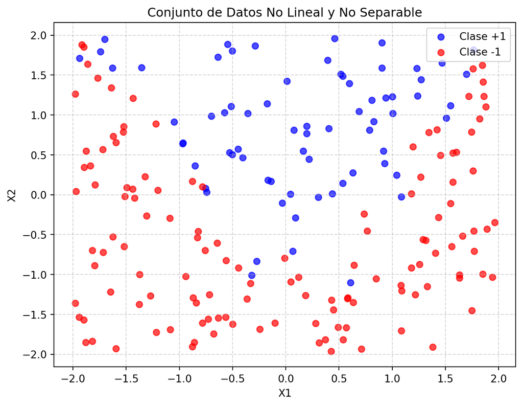

```python
import numpy as np
import matplotlib.pyplot as plt
import cvxpy as cp

# Semilla para reproducibilidad
np.random.seed(42)

# Generar datos en 2D
n_samples = 200
X = np.random.uniform(-2, 2, (n_samples, 2))

# Frontera parabólica x2 = 0.8 * x1^2 - 0.7 con ruido gaussiano
ruido = np.random.normal(0, 0.45, n_samples)
y_val = X[:, 1] - (0.8 * X[:, 0]**2 - 0.7) + ruido
Y = np.where(y_val >= 0, 1, -1)

# Visualización del conjunto de datos
plt.figure(figsize=(8, 6))
plt.scatter(X[Y == 1][:, 0], X[Y == 1][:, 1], label='Clase +1', color='blue', alpha=0.7)
plt.scatter(X[Y == -1][:, 0], X[Y == -1][:, 1], label='Clase -1', color='red', alpha=0.7)
plt.xlabel('X1')
plt.ylabel('X2')
plt.title('Conjunto de Datos No Lineal y No Separable')
plt.legend()
plt.grid(True, linestyle='--', alpha=0.5)
plt.show()
```

# 2 Parte 1: Propuesta del mapeo explícito $\phi(\mathbf{x})$

## 2.1 Ejercicio 1.1: Justificación geométrica

Observa la distribución espacial de los puntos en la gráfica anterior.

- **Pregunta**: ¿Qué tipo de curva separa aproximadamente las dos clases?
  - **Respuesta**: La frontera entre ambas clases sigue una forma parabólica cuadrática de la forma $x_2 \approx 0.8 x_1^2 - 0.7$.
- **Propuesta**: Definimos una función de mapeo polinomial cuadrática $\phi: \mathbb{R}^2 \to \mathbb{R}^3$:

$$\phi(x_1, x_2) = (x_1, x_2, x_1^2)$$

Al incorporar la característica cuadrática $x_1^2$, la frontera de separación $x_2 - 0.8 x_1^2 + 0.7 = 0$ se convierte en un plano lineal en $\mathbb{R}^3$ definido por $w_1 z_1 + w_2 z_2 + w_3 z_3 + b = 0$.

## 2.2 Ejercicio 1.2: Implementación del mapeo

Implementamos en Python la función `phi(X)` que aplica la transformación cuadrática a la matriz de características `X`:

```python
def phi(X):
    """
    Transforma la matriz X de dimensión (n, 2) a (n, 3)
    añadiendo el término cuadrático x1^2.
    """
    return np.column_stack((X[:, 0], X[:, 1], X[:, 0]**2))

X_transformed = phi(X)
print("Forma de X_transformed:", X_transformed.shape)
```

```
Forma de X_transformed: (200, 3)
```

# 3 Parte 2: Formulación primal soft-margin en el espacio transformado

Usando los datos transformados $\mathbf{X}_{\text{transformed}} = \phi(\mathbf{X})$, resolvemos el problema primal con margen suave (*Soft-Margin*):

$$\begin{aligned}
\min_{\mathbf{w}, b, \boldsymbol{\xi}} \quad & \frac{1}{2} \|\mathbf{w}\|_2^2 + C \sum_{i=1}^n \xi_i \\
\text{sujeto a} \quad & y_i (\mathbf{w}^T \phi(\mathbf{x}_i) + b) \geq 1 - \xi_i, \quad i = 1, \ldots, n \\
& \xi_i \geq 0, \quad i = 1, \ldots, n
\end{aligned}$$

## 3.1 Ejercicio 2.1: Resolución con CVXPY

Fijamos $C = 0.5$, definimos y resolvemos el problema de optimización en CVXPY:

```python
C = 0.5
n, d = X_transformed.shape

w = cp.Variable(d)
b = cp.Variable()
xi = cp.Variable(n)

objective = cp.Minimize(0.5 * cp.square(cp.norm(w)) + C * cp.sum(xi))
constraints = [
    cp.multiply(Y, X_transformed @ w + b) >= 1 - xi,
    xi >= 0
]

prob = cp.Problem(objective, constraints)
prob.solve()

w_opt = w.value
b_opt = b.value

print("Valor óptimo de w:", w_opt)
print("Valor óptimo de b:", b_opt)
```

```
Valor óptimo de w: [ 0.05310351  2.00635618 -1.61133083]
Valor óptimo de b: 1.1961891371152558
```

## 3.2 Ejercicio 2.2: Visualización de la frontera de decisión en $\mathbb{R}^2$

Representamos en el espacio bidimensional original el límite de decisión proyectado y calculamos la exactitud (*accuracy*):

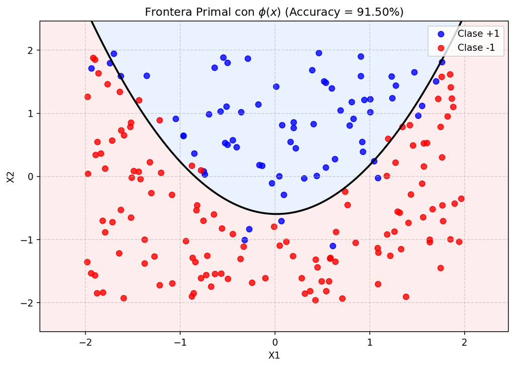

```python
# Crear malla de puntos en 2D
x1_min, x1_max = X[:, 0].min() - 0.5, X[:, 0].max() + 0.5
x2_min, x2_max = X[:, 1].min() - 0.5, X[:, 1].max() + 0.5
xx1, xx2 = np.meshgrid(np.linspace(x1_min, x1_max, 200), np.linspace(x2_min, x2_max, 200))
X_grid = np.c_[xx1.ravel(), xx2.ravel()]
X_grid_phi = phi(X_grid)

# Predicción en la malla
Z_primal = (X_grid_phi @ w_opt + b_opt).reshape(xx1.shape)
predicciones_primal = np.sign(X_transformed @ w_opt + b_opt)
acc_primal = np.mean(predicciones_primal == Y)

plt.figure(figsize=(9, 6))
plt.contourf(xx1, xx2, Z_primal, levels=[-np.inf, 0, np.inf], colors=['#fee2e2', '#dbeafe'], alpha=0.6)
plt.contour(xx1, xx2, Z_primal, levels=[0], colors='black', linewidths=2.0)
plt.scatter(X[Y == 1][:, 0], X[Y == 1][:, 1], label='Clase +1', color='blue', alpha=0.8)
plt.scatter(X[Y == -1][:, 0], X[Y == -1][:, 1], label='Clase -1', color='red', alpha=0.8)
plt.xlabel('X1')
plt.ylabel('X2')
plt.title(f'Frontera Primal con $\phi(x)$ (Accuracy = {acc_primal:.2%})')
plt.legend()
plt.grid(True, linestyle='--', alpha=0.5)
plt.show()
```

# 4 Parte 3: Formulación dual y kernel trick (RBF)

Ahora utilizaremos la formulación dual con el *kernel trick* utilizando un kernel Gaussiano (RBF):

$$K(\mathbf{x}_i, \mathbf{x}_j) = \exp(-\gamma \|\mathbf{x}_i - \mathbf{x}_j\|_2^2)$$

El problema dual a resolver es:

$$\begin{aligned}
\min_{\boldsymbol{\alpha}} \quad & \frac{1}{2} \boldsymbol{\alpha}^T \mathbf{H} \boldsymbol{\alpha} - \mathbf{1}^T \boldsymbol{\alpha} \\
\text{sujeto a} \quad & \mathbf{y}^T \boldsymbol{\alpha} = 0 \\
& 0 \leq \alpha_i \leq C, \quad i = 1, \ldots, n
\end{aligned}$$

donde $H_{ij} = y_i y_j K(\mathbf{x}_i, \mathbf{x}_j)$.

## 4.1 Ejercicio 3.1: Construcción de la matriz de Gram y resolución

Calculamos la matriz $\mathbf{H}$ para $\gamma = 1.0$ y resolvemos el problema dual con CVXPY utilizando $C = 0.5$:

```python
gamma = 1.0
C = 0.5

# Matriz de distancias cuadráticas euclídeas
sq_dists = np.sum(X**2, axis=1).reshape(-1, 1) + np.sum(X**2, axis=1) - 2 * (X @ X.T)
K_rbf = np.exp(-gamma * sq_dists)
H = (Y.reshape(-1, 1) @ Y.reshape(1, -1)) * K_rbf

# Problema dual en CVXPY
alpha = cp.Variable(n)
obj_dual = cp.Minimize(0.5 * cp.quad_form(alpha, cp.psd_wrap(H)) - cp.sum(alpha))
constraints_dual = [
    Y @ alpha == 0,
    alpha >= 0,
    alpha <= C
]

prob_dual = cp.Problem(obj_dual, constraints_dual)
prob_dual.solve()
alpha_opt = alpha.value

print("Suma de alpha_i:", np.sum(alpha_opt))
```

```
Suma de alpha_i: 35.04055640633132
```

## 4.2 Ejercicio 3.2: Clasificación de vectores de soporte (condiciones KKT)

Identificamos los vectores soporte utilizando un umbral de tolerancia $\epsilon = 10^{-4}$:

```python
tol = 1e-4
sv_free = (alpha_opt > tol) & (alpha_opt < C - tol)
sv_bounded = np.abs(alpha_opt - C) < tol
all_sv = (alpha_opt > tol)

# Calcular el término de sesgo b a partir de los vectores de soporte libres
b_rbf_list = []
for idx in np.where(sv_free)[0]:
    b_k = Y[idx] - np.sum(alpha_opt * Y * K_rbf[:, idx])
    b_rbf_list.append(b_k)

b_rbf = np.mean(b_rbf_list) if len(b_rbf_list) > 0 else 0.0

print(f"Vectores de soporte en el margen (0 < alpha < C): {np.sum(sv_free)}")
print(f"Vectores de soporte que violan el margen (alpha = C): {np.sum(sv_bounded)}")
print(f"Sesgo b estimado: {b_rbf:.4f}")
```

```
Vectores de soporte en el margen (0 < alpha < C): 17
Vectores de soporte que violan el margen (alpha = C): 61
Sesgo b estimado: -0.4733
```

## 4.3 Ejercicio 3.3: Visualización de la frontera dual

Dibujamos el límite de decisión obtenido con el kernel RBF e hipermarcamos los vectores de soporte:

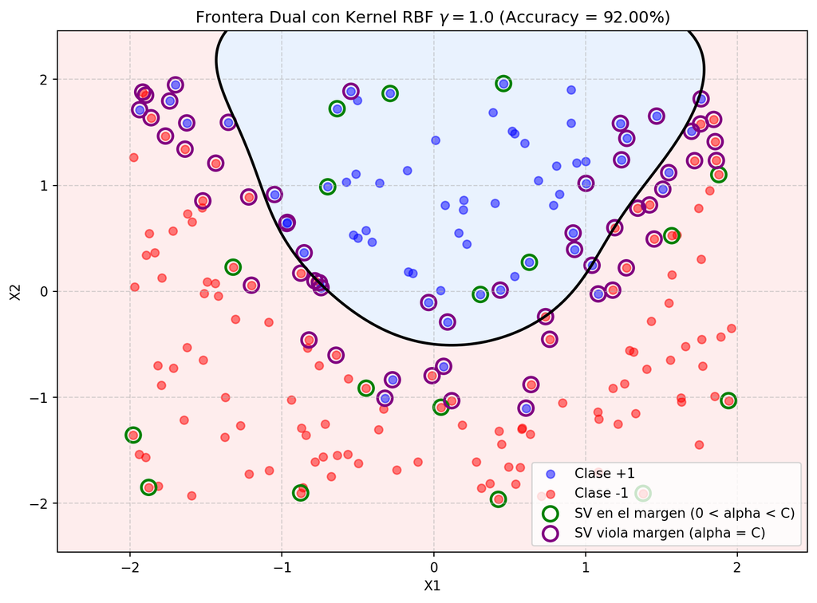

```python
# Calcular decisión en la malla X_grid
sq_dists_grid = np.sum(X_grid**2, axis=1).reshape(-1, 1) + np.sum(X**2, axis=1) - 2 * (X_grid @ X.T)
K_grid = np.exp(-gamma * sq_dists_grid)
Z_rbf = (K_grid @ (alpha_opt * Y) + b_rbf).reshape(xx1.shape)

predicciones_rbf = np.sign(K_rbf @ (alpha_opt * Y) + b_rbf)
acc_rbf = np.mean(predicciones_rbf == Y)

plt.figure(figsize=(10, 7))
plt.contourf(xx1, xx2, Z_rbf, levels=[-np.inf, 0, np.inf], colors=['#fee2e2', '#dbeafe'], alpha=0.6)
plt.contour(xx1, xx2, Z_rbf, levels=[0], colors='black', linewidths=2.0)

# Muestras
plt.scatter(X[Y == 1][:, 0], X[Y == 1][:, 1], label='Clase +1', color='blue', alpha=0.5)
plt.scatter(X[Y == -1][:, 0], X[Y == -1][:, 1], label='Clase -1', color='red', alpha=0.5)

# Vectores soporte destacados
plt.scatter(X[sv_free][:, 0], X[sv_free][:, 1], s=120, facecolors='none', edgecolors='green', linewidths=2, label='SV en el margen (0 < alpha < C)')
plt.scatter(X[sv_bounded][:, 0], X[sv_bounded][:, 1], s=120, facecolors='none', edgecolors='purple', linewidths=2, label='SV viola margen (alpha = C)')

plt.xlabel('X1')
plt.ylabel('X2')
plt.title(f'Frontera Dual con Kernel RBF $\gamma={gamma}$ (Accuracy = {acc_rbf:.2%})')
plt.legend()
plt.grid(True, linestyle='--', alpha=0.5)
plt.show()
```

# 5 Parte 4: Discusión comparativa

Responde brevemente a las siguientes preguntas razonando las respuestas:

1. **Comparación de fronteras**:
   - *Respuesta*: El mapeo explícito $\phi(\mathbf{x}) = (x_1, x_2, x_1^2)$ genera una parábola rígida en $\mathbb{R}^2$. En cambio, el Kernel RBF genera una frontera suave y curvada que se adapta mejor a las irregularidades locales producidas por el ruido.
2. **Ventajas del dual**:
   - *Respuesta*: El Kernel RBF trabaja en un espacio de características de dimensión infinita sin necesidad de calcular ni almacenar vectores transformados de alta dimensión. Evita la maldición de la dimensionalidad y simplifica la computación a evaluar productos escalares implícitos en $\mathbf{H}$.
3. **Efecto de los parámetros**:
   - *Respuesta*: Si incrementamos $\gamma$ a un valor muy elevado (ej. $\gamma = 50$), la función Gaussiana se vuelve muy estrecha. La frontera rodeará cada punto individualmente creando “islas” de decisión muy complejas, lo que provocará **sobreajuste (*overfitting*)** y una pérdida drástica en la capacidad de generalización del modelo.